# [VHH] Naive Assembly

2023-11-16

This assembly process is derived from [Immcantation Documentation: Illumina MiSeq 2x250 BCR mRNA](https://presto.readthedocs.io/en/stable/workflows/Greiff2014_Workflow.html)

Schematically:

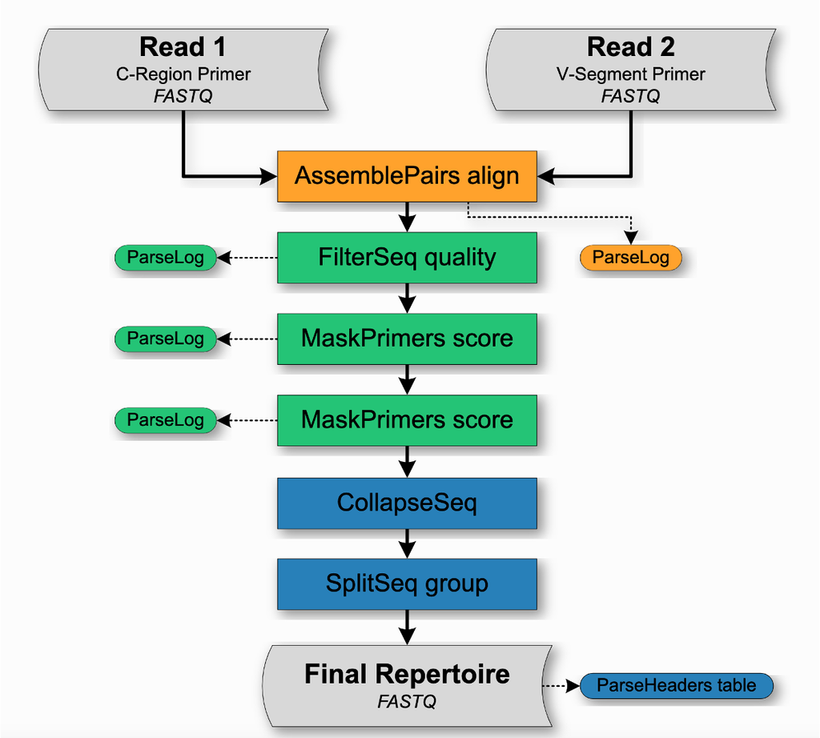

### (1) Paired-End Assembly (a bit).

```bash
docker run -v /Users/emoseley/VHH/data:/data  immcantation/suite:4.4.0  \
  AssemblePairs.py align -1 /data/1_3_S1_L001_R2_001.fastq -2 /data/1_3_S1_L001_R1_001.fastq \
  --coord illumina --rc tail --maxerror 0.1 \
  --outname S1
```

```
docker run -v /Users/emoseley/VHH/data:/data  immcantation/suite:4.4.0  \
  AssemblePairs.py align -1 /data/1_3_S1_L001_R2_001.fastq -2 /data/1_3_S1_L001_R1_001.fastq \
  --coord illumina --rc tail --maxerror 0.1 \
  --outname S1


       START> AssemblePairs
     COMMAND> align
       FILE1> 1_3_S1_L001_R2_001.fastq
       FILE2> 1_3_S1_L001_R1_001.fastq
  COORD_TYPE> illumina
       ALPHA> 1e-05
   MAX_ERROR> 0.1
     MIN_LEN> 8
     MAX_LEN> 1000
SCAN_REVERSE> False
       NPROC> 6

PROGRESS> 15:20:10 |####################| 100% (216,163) 9.3 min

OUTPUT> S1_assemble-pass.fastq
 PAIRS> 216163
  PASS> 161468
  FAIL> 54695
   END> AssemblePairs
```

### (2) Filter Poor Alignments

```bash
docker run -v /Users/emoseley/VHH/data:/data immcantation/suite:4.4.0  \
  FilterSeq.py quality -s /data/S1_assemble-pass.fastq -q 20 --outname S1
```

```
docker run -v /Users/emoseley/VHH/data:/data immcantation/suite:4.4.0  \
  FilterSeq.py quality -s /data/S1_assemble-pass.fastq -q 20 --outname S1
   START> FilterSeq
 COMMAND> quality
    FILE> S1_assemble-pass.fastq
   INNER> False
MIN_QUAL> 20.0
   NPROC> 6

PROGRESS> 15:47:00 |####################| 100% (161,468) 1.1 min

   OUTPUT> S1_quality-pass.fastq
SEQUENCES> 161468
     PASS> 158698
     FAIL> 2770
      END> FilterSeq
```

## (3) Mask Primers

Note: “read 2 is VPRIMER region”

```bash
docker run -v /Users/emoseley/VHH/data:/data immcantation/suite:4.4.0  \
MaskPrimers.py score -s /data/S1_quality-pass.fastq -p /data/AlpVHH_R2_12Nov23.fasta \
    --start 0 --mode mask --pf VPRIMER --outname S1-FWD --log /data/MPV.log
```

```
docker run -v /Users/emoseley/VHH/data:/data immcantation/suite:4.4.0  \
MaskPrimers.py score -s /data/S1_quality-pass.fastq -p /data/AlpVHH_R2_12Nov23.fasta \
    --start 0 --mode mask --pf VPRIMER --outname S1-FWD --log /data/MPV.log
       START> MaskPrimers
     COMMAND> score
    SEQ_FILE> S1_quality-pass.fastq
 PRIMER_FILE> AlpVHH_R2_12Nov23.fasta
        MODE> mask
   MAX_ERROR> 0.2
   START_POS> 0
  REV_PRIMER> False
     BARCODE> False
PRIMER_FIELD> VPRIMER
       NPROC> 6

PROGRESS> 16:38:30 |####################| 100% (158,698) 2.0 min

   OUTPUT> S1-FWD_primers-pass.fastq
SEQUENCES> 158698
     PASS> 157559
     FAIL> 1139
      END> MaskPrimers
```

```bash
docker run -v /Users/emoseley/VHH/data:/data immcantation/suite:4.4.0  \
MaskPrimers.py score -s /data/S1_quality-pass.fastq -p /data/AlpVHH_R1_12Nov23.fasta \
    --start 0 --mode mask --revpr --pf CPRIMER --outname S1-REV --log /data/MPC.log
```

```
docker run -v /Users/emoseley/VHH/data:/data immcantation/suite:4.4.0  \
MaskPrimers.py score -s /data/S1_quality-pass.fastq -p /data/AlpVHH_R1_12Nov23.fasta \
    --start 0 --mode mask --revpr --pf CPRIMER --outname S1-REV --log /data/MPC.log
       START> MaskPrimers
     COMMAND> score
    SEQ_FILE> S1_quality-pass.fastq
 PRIMER_FILE> AlpVHH_R1_12Nov23.fasta
        MODE> mask
   MAX_ERROR> 0.2
   START_POS> 0
  REV_PRIMER> True
     BARCODE> False
PRIMER_FIELD> CPRIMER
       NPROC> 6

PROGRESS> 16:23:33 |####################| 100% (158,698) 2.4 min

   OUTPUT> S1-REV_primers-pass.fastq
SEQUENCES> 158698
     PASS> 157364
     FAIL> 1334
      END> MaskPrimers
```

#### Parse logs for a sanity check

```bash
docker run -v /Users/emoseley/VHH/data:/data immcantation/suite:4.4.0  \
  ParseLog.py -l /data/MPV.log /data/MPC.log -f ID PRIMER ERROR
```

```
docker run -v /Users/emoseley/VHH/data:/data immcantation/suite:4.4.0  \
  ParseLog.py -l /data/MPV.log /data/MPC.log -f ID PRIMER ERROR
START> ParseLog
 FILE> MPV.log

PROGRESS> 16:42:14 (158698) 0.1 min

 OUTPUT> MPV_table.tab
RECORDS> 158698
   PASS> 158698
   FAIL> 0
    END> ParseLog

START> ParseLog
 FILE> MPC.log

PROGRESS> 16:42:19 (158698) 0.1 min

 OUTPUT> MPC_table.tab
RECORDS> 158698
   PASS> 158698
   FAIL> 0
    END> ParseLog
```

```r
tmp <- read.csv("~/VHH/data/MPC_table.tab", sep = '\t', header = T, stringsAsFactors = F)
tableone::CreateTableOne("ERROR", "PRIMER", tmp)
```

```
##                    Stratified by PRIMER
##                     rev_comp_mplex_read_two_primer rev_comp_short_hinge
##   n                   11                            434
##   ERROR (mean (SD)) 0.69 (0.06)                    0.69 (0.02)
##                    Stratified by PRIMER
##                     vhh_forward   p      test
##   n                 158253
##   ERROR (mean (SD))   0.00 (0.04) <0.001
```

```r
rm(tmp)
```

## (4) Deduplication and Filtering

The last stage of the workflow involves two filtering steps to yield the final repertoire. First, the set of unique sequences is identified using the `CollapseSeq.py`tool, allowing for up to 20 interior N-valued positions (`-n 20` and `--inner`), and **you requiring that all reads considered duplicates share the same C-region primer annotation (`--uf CPRIMER`)**. Additionally, the V-segment primer annotations of the set of duplicate reads are propagated into the annotation of each retained unique sequence (`--cf VPRIMER` and `--act set`):

```bash
docker run -v /Users/emoseley/VHH/data:/data immcantation/suite:4.4.0  \
CollapseSeq.py -s /data/S1-REV_primers-pass.fastq -n 20 --inner --uf CPRIMER \
    --cf VPRIMER --act set --outname S1
```

```
docker run -v /Users/emoseley/VHH/data:/data immcantation/suite:4.4.0  \
CollapseSeq.py -s /data/S1-REV_primers-pass.fastq -n 20 --inner --uf CPRIMER \
    --cf VPRIMER --act set --outname S1

       START> CollapseSeq
        FILE> S1-REV_primers-pass.fastq
 MAX_MISSING> 20
 UNIQ_FIELDS> CPRIMER
 COPY_FIELDS> VPRIMER
COPY_ACTIONS> set
   MAX_FIELD> None
   MIN_FIELD> None
       INNER> True
KEEP_MISSING> False

PROGRESS> [0 missing] 16:51:47 |####################| 100% (157,364) 0.1 min

      OUTPUT> S1_collapse-unique.fastq
   SEQUENCES> 157364
      UNIQUE> 123826
   DUPLICATE> 33538
UNDETERMINED> 0
         END> CollapseSeq
```

`CollapseSeq` stores the count of duplicate reads for each sequence in the `DUPCOUNT` annotation. Following duplicate removal, the data is subset to only those unique sequence with at least two representative reads by using the group subcommand of `SplitSeq.py` on the count field (`-f DUPCOUNT`) and specifying a numeric threshold (`--num 2`):

```bash
docker run -v /Users/emoseley/VHH/data:/data immcantation/suite:4.4.0  \
  SplitSeq.py group -s /data/S1_collapse-unique.fastq -f DUPCOUNT --num 2 --outname S1
```

```
docker run -v /Users/emoseley/VHH/data:/data immcantation/suite:4.4.0  \
  SplitSeq.py group -s /data/S1_collapse-unique.fastq -f DUPCOUNT --num 2 --outname S1
    START> SplitSeq
  COMMAND> group
     FILE> S1_collapse-unique.fastq
    FIELD> DUPCOUNT
THRESHOLD> 2.0

PROGRESS> 16:54:11 |####################| 100% (123,826) 0.6 min

  OUTPUT1> S1_under-2.fastq
  OUTPUT2> S1_atleast-2.fastq
SEQUENCES> 123826
    PARTS> 2
      END> SplitSeq
```

## (5) Creating an annotation table

Finally, the annotations, including duplicate read count (`DUPCOUNT`), isotype (`CPRIMER`) and V-segment primer (`VPRIMER`), of the final repertoire are then extracted from the `SplitSeq.py` output into a tab-delimited file using the table subcommand of `ParseHeaders.py`:

```bash
docker run -v /Users/emoseley/VHH/data:/data immcantation/suite:4.4.0  \
  ParseHeaders.py table -s /data/S1_atleast-2.fastq -f ID DUPCOUNT CPRIMER VPRIMER
```

```
docker run -v /Users/emoseley/VHH/data:/data immcantation/suite:4.4.0  \
  ParseHeaders.py table -s /data/S1_atleast-2.fastq -f ID DUPCOUNT CPRIMER VPRIMER
  START> ParseHeaders
COMMAND> table
   FILE> S1_atleast-2.fastq

PROGRESS> 16:55:31 |####################| 100% (7,747) 0.0 min

   OUTPUT> S1_atleast-2_headers.tab
SEQUENCES> 7747
     PASS> 7747
     FAIL> 0
      END> ParseHeaders
```

#### Check log

```r
tmp <- read.csv("~/VHH/data/S1_atleast-2_headers.tab", sep = '\t', header = T, stringsAsFactors = F)

# CPrimer is unmasked
table(tmp$CPRIMER)
```

```
##
## vhh_forward
##        7747
```

```r
# VPrimer is masked
table(tmp$VPRIMER)
```

```
##
## None
## 7747
```

### Prep for IMGT

```
# Copy over the file
cp S1_atleast-2.fastq ~/ncbi-igblast-1.17.1/
# Change the directory
cd ~/ncbi-igblast-1.17.1
```

## Convert the file to fasta

```r
# Arguments
args <- c("S1_atleast-2.fastq")
# args = commandArgs(trailingOnly=TRUE)

# Directory
directory <- "/Users/emoseley/VHH/data/"

# Set current working directory to ncbi-igblast-1.17.1
setwd("~/ncbi-igblast-1.17.1")

file_origin <- paste("~/ncbi-igblast-1.17.1/", args[1], sep = '')
file_output <- gsub(".fastq", ".fasta", file_origin)
results <- gsub(".fastq", '.fmt7', args)
```

### IMGT

```bash
bin/igblastn -germline_db_V database/alpaca_vhh_clean/alpaca_V -germline_db_D database/alpaca_vhh_clean/alpaca_D -germline_db_J database/alpaca_vhh_clean/alpaca_J -domain_system imgt -ig_seqtype Ig -organism alpaca -auxiliary_data optional_file/alpaca_gl.aux -outfmt '7 std qseq sseq btop' -query ~/ncbi-igblast-1.17.1/S1_atleast-2.fasta -out ~/ncbi-igblast-1.17.1/S1_atleast-2.fmt7
```

```
# Copy back to data
cp S1_atleast-2.fmt7 ~/VHH/data
cp S1_atleast-2.fasta ~/VHH/data
```

### Make Database

```bash
docker run -v /Users/emoseley/VHH/data:/data immcantation/suite:4.4.0 \
  MakeDb.py igblast -i /data/S1_atleast-2.fmt7 -s /data/S1_atleast-2.fasta \
  -r /data/imgt-data/imgt_gapped_alpaca_IGHV.fasta \
  /data/imgt-data/imgt_gapped_alpaca_IGHD.fasta  \
  /data/imgt-data/imgt_gapped_alpaca_IGHJ.fasta \
  --outdir /data/ --failed --format airr --extended
```

```
docker run -v /Users/emoseley/VHH/data:/data immcantation/suite:4.4.0 \
  MakeDb.py igblast -i /data/S1_atleast-2.fmt7 -s /data/S1_atleast-2.fasta \
  -r /data/imgt-data/imgt_gapped_alpaca_IGHV.fasta \
  /data/imgt-data/imgt_gapped_alpaca_IGHD.fasta  \
  /data/imgt-data/imgt_gapped_alpaca_IGHJ.fasta \
  --outdir /data/ --failed --format airr --extended

         START> MakeDB
       COMMAND> igblast
  ALIGNER_FILE> S1_atleast-2.fmt7
      SEQ_FILE> S1_atleast-2.fasta
       ASIS_ID> False
    ASIS_CALLS> False
      VALIDATE> strict
      EXTENDED> True
INFER_JUNCTION> False

PROGRESS> 17:25:21 |Done                | 0.0 min

PROGRESS> 17:25:45 |####################| 100% (7,747) 0.4 min

OUTPUT> S1_atleast-2_db-pass.tsv
  PASS> 6509
  FAIL> 1238
   END> MakeDb
```